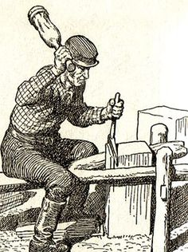

# Projects

## Software

- [`bycatch`](https://ericward-noaa.github.io/bycatch/) R package  
  This is a repository for applications of Bayesian bycatch models, using Stan for estimation. These models fit Bayesian GLMs (with or without time varying parameters, and with or without covariates) to estimate fleet-level bycatch rates. The primary applications of these models are protected species bycatch (e.g., ESA listed birds, marine mammals, sea turtles) in the groundfish fisheries off the west coast of the USA. Data compilation and analysis is done at the Northwest Fisheries Science Center (NWFSC) in Seattle. This is part of the [NOAA Fisheries Integrated Toolbox](https://noaa-fisheries-integrated-toolbox.github.io/).

## Fisheries Management

- 2023-2025 - Lead the implementation of new mechanisms for monitoring trawl pollock catcher vessels in the Bering Sea and Gulf of Alaska, in collaboration with Alaska Regional Office, the fishing industry, and [NPFMC](https://www.npfmc.org/).
- 2023-present - Annual Deployment Plan - Lead the development of cost-effective and scientifically sound method for deploying fisheries observers and electronic monitoring in the groundfish and Pacific halibut fisheries off the coast of Alaska, USA ([link](https://www.fisheries.noaa.gov/s3//2024-11/Final_2025_ADP.pdf)), in collaboration with the Alaska Regional Office, the fishing industry, and [NPFMC](https://www.npfmc.org/).
- 2023-present - North Pacific Observer Program Annual Reporting - Lead the report on the performance of fishery observer and electronic monitoring deployment into the groundfish and Pacific halibut fisheries off the coast of Alaska, USA ([link](https://repository.library.noaa.gov/view/noaa/66036)), in collaboration with the Alaska Regional Office, the fishing industry, and [NPFMC](https://www.npfmc.org/).
- 2023-2024 - Lead development of new technology for fisheries observers to document potential fisheries regulatory violations to the NOAA Office of Law Enforcement.
- 2020-2022 - NOAA’s National Bycatch Reduction Engineering Program.
- 2018-2022 - Seabird advisory and management bodies including: NOAA’s National Seabird Program Strategic Implementation Team, USFWS Short-tailed Albatross Recovery Team, Agreement on the Conservation of Albatross and Petrels, and the North Pacific Albatross Work Group.
- 2013-2022 - Pacific Fishery Management Council’s [Groundfish Endangered Species Workgroup](https://www.pcouncil.org/navigating-the-council/membership-groups-and-staff/advisory-groups/groundfish-endangered-species-workgroup/): I led the reporting of fisheries bycatch of 5 species listed on the U.S. Endangered Species Act that interact with fisheries off the U.S. West Coast: humpback whales, leatherback sea turtles, short-tailed albatross, green sturgeon, and eulachon smelt.
- 2011-2022 - Annual Pacific halibut (*Hippoglossus stenolepis*) bycatch in fisheries off the U.S. West Coast.